# Parry_2023a_bulkRNA-seq_analysis

Author

Pakorn Sagulkoo

In this code we will analyse bulk RNA-seq between Richter’s transformation (RT) and chronic lymphocytic leukaemia (CLL) patients. The data comes from [Parry et al. (2023a)](https://www.nature.com/articles/s41591-022-02113-6). After we performed Salmon to convert FASTQ files to pseudocount data in each sample, in this code we will convert them to a count matrix before we use the matrix for DESeq2 for further gene expression analysis.

## Import the relevant packages and set working path directory

```r
# Import the relavant packages
library(tximport)
library(ensembldb)
library(dplyr)
library(stringr)
library(ggplot2)
library(ggrepel)
library(DESeq2)
```

```r
# Check root path
here::here()
```

```
[1] "/mnt/hp-storage/users/pakorns"
```

## Define paths

```r
# Define paths to load and save files
path_to_samples <- here::here("RNAseq/Parry_2023a")
path_to_sample_metadata <- here::here("RNAseq/systematic_review/2-Parry_2023a/sample_metadata.csv")
path_to_ref_transcriptome <- "/home/pakorns/hc-storage/fastq_files/RNAseq/transcriptome_ref"
path_to_save_txi <- here::here("RNAseq/systematic_review/2-Parry_2023a/count_matrices/Parry_txi.rds")
path_to_save_dea <- here::here("RNAseq/systematic_review/2-Parry_2023a/expression_data/Parry_dea.rds")
path_to_save_hm_gsea <- here::here("RNAseq/systematic_review/2-Parry_2023a/enrichment_data/Parry_hm_gsea.rds")
path_to_save_go_gsea <- here::here("RNAseq/systematic_review/2-Parry_2023a/enrichment_data/Parry_go_gsea.rds")
```

## Load data and functions

```r
# Source functions
source(here::here("bin/utils.R"))
```

```r
# Load sample metadata
sample_metadata <- read.csv(path_to_sample_metadata)
DT::datatable(sample_metadata, options = list(scrollX = TRUE))
```

|  | Run | Assay.Type | biospecimen_repository_sample_id | is_tumor | histological_type | case | tissue |
| --- | --- | --- | --- | --- | --- | --- | --- |
| 1 | SRR22839006 | RNA-Seq | GCLL-0360-T-01 | Yes | CLL | 24 | PB |
| 2 | SRR22839010 | RNA-Seq | GCLL-0360-R-01 | Yes | RS | 24 | BM |
| 3 | SRR22839013 | RNA-Seq | GCLL-0355-R-01 | Yes | RS | 19 | LN |
| 4 | SRR22839018 | RNA-Seq | GCLL-0355-T-01 | Yes | CLL | 19 | PB |
| 5 | SRR22956586 | RNA-Seq | GCLL-0353-T-01 | Yes | CLL | 27 | PB |
| 6 | SRR22960566 | RNA-Seq | GCLL-0358-R-01 | Yes | RS | 7 | LN |
| 7 | SRR22960567 | RNA-Seq | GCLL-0358-T-01 | Yes | CLL | 7 | PB |
| 8 | SRR22964505 | RNA-Seq | GCLL-0347-R-01 | Yes | RS | 42 | LN |
| 9 | SRR22964506 | RNA-Seq | GCLL-0347-T-01 | Yes | CLL | 42 | PB |
| 10 | SRR22964520 | RNA-Seq | GCLL-0353-R-01 | Yes | RS | 27 | LN |

```r
# Create a vector collecting Salmon quant.sf path in each sample
path_to_download <- str_c(path_to_samples, "/", sample_metadata$Run, "/quant.sf")
names(path_to_download) <- sample_metadata$Run
path_to_download
```

```
                                                            SRR22839006
"/mnt/hp-storage/users/pakorns/RNAseq/Parry_2023a/SRR22839006/quant.sf"
                                                            SRR22839010
"/mnt/hp-storage/users/pakorns/RNAseq/Parry_2023a/SRR22839010/quant.sf"
                                                            SRR22839013
"/mnt/hp-storage/users/pakorns/RNAseq/Parry_2023a/SRR22839013/quant.sf"
                                                            SRR22839018
"/mnt/hp-storage/users/pakorns/RNAseq/Parry_2023a/SRR22839018/quant.sf"
                                                            SRR22956586
"/mnt/hp-storage/users/pakorns/RNAseq/Parry_2023a/SRR22956586/quant.sf"
                                                            SRR22960566
"/mnt/hp-storage/users/pakorns/RNAseq/Parry_2023a/SRR22960566/quant.sf"
                                                            SRR22960567
"/mnt/hp-storage/users/pakorns/RNAseq/Parry_2023a/SRR22960567/quant.sf"
                                                            SRR22964505
"/mnt/hp-storage/users/pakorns/RNAseq/Parry_2023a/SRR22964505/quant.sf"
                                                            SRR22964506
"/mnt/hp-storage/users/pakorns/RNAseq/Parry_2023a/SRR22964506/quant.sf"
                                                            SRR22964520
"/mnt/hp-storage/users/pakorns/RNAseq/Parry_2023a/SRR22964520/quant.sf"
```

## Convert salmon pseudocounts to an expression matrix

```r
# Load the ensembl hg38 gtf file
path_to_hg38_transcriptome <- str_c(path_to_ref_transcriptome, "/Homo_sapiens.GRCh38.115.gtf.gz")
edb <- ensDbFromGtf(path_to_hg38_transcriptome) # Return edb = "./Homo_sapiens.GRCh38.115.sqlite"
```

```r
# Make the transcript-to-gene map (tx2gene)
edb <- "./Homo_sapiens.GRCh38.115.sqlite"
edb_obj <- EnsDb(edb)
tx2gene <- transcripts(edb_obj,
                       columns = c("tx_id","gene_id","gene_name"),
                       return.type="DataFrame")

# convert to a plain data.frame for tximport
tx2gene <- as.data.frame(tx2gene)
head(tx2gene)
```

```
            tx_id         gene_id gene_name
1 ENST00000000233 ENSG00000004059      ARF5
2 ENST00000000412 ENSG00000003056      M6PR
3 ENST00000000442 ENSG00000173153     ESRRA
4 ENST00000001008 ENSG00000004478     FKBP4
5 ENST00000001146 ENSG00000003137   CYP26B1
6 ENST00000002125 ENSG00000003509   NDUFAF7
```

```r
# Load pseudocount files
txi <- tximport(path_to_download,
                type = "salmon",
                tx2gene = tx2gene,
                ignoreTxVersion = TRUE
               )

# This gives you txi$counts, txi$abundance (TPM), txi$length
head(txi$counts)
```

```
                SRR22839006 SRR22839010 SRR22839013 SRR22839018 SRR22956586
ENSG00000000003       4.989       3.000      28.075       8.029       1.000
ENSG00000000005       0.000       0.000       1.000       0.000       0.000
ENSG00000000419    2085.762     653.367    4622.426    2024.189     927.310
ENSG00000000457    1310.330     191.481    1145.850    1468.327     606.653
ENSG00000000460     977.985     148.218    2062.683     440.065     232.997
ENSG00000000938   22380.438    6848.116     406.989    1349.164    6795.003
                SRR22960566 SRR22960567 SRR22964505 SRR22964506 SRR22964520
ENSG00000000003       8.001       3.999       1.069       7.969      24.006
ENSG00000000005       0.000       0.000       0.000       0.000       0.000
ENSG00000000419    2133.268    1414.923    2976.721    1785.984    1691.986
ENSG00000000457    1220.019     946.109     965.080     324.120     886.952
ENSG00000000460    1771.907     501.792     826.070     326.253     810.453
ENSG00000000938    2749.915    4791.377    3385.570    4368.497    6227.726
```

```r
# Save the expression file
saveRDS(txi, path_to_save_txi)
```

## Transcriptomics analysis using DESeq2

```r
# Import the relevant package
library(DESeq2)
library(limma)
```

### Create a DESeq2 object

```r
# Create metadata for DESeq2 object
colData <- sample_metadata[, c("Run", "histological_type", "case")] %>%
  rename(
    samples = "Run",
    condition = "histological_type"
  ) %>%
  mutate(
    batch = ifelse(case == "7", 1,
                   ifelse(case == "19", 2,
                          ifelse(case == "24", 3,
                                 ifelse(case == "27", 4, 5))))
  )

rownames(colData) <- colData$samples
colData$condition <- factor(colData$condition)
colData$batch <- factor(colData$batch)
colData
```

```
                samples condition case batch
SRR22839006 SRR22839006       CLL   24     3
SRR22839010 SRR22839010        RS   24     3
SRR22839013 SRR22839013        RS   19     2
SRR22839018 SRR22839018       CLL   19     2
SRR22956586 SRR22956586       CLL   27     4
SRR22960566 SRR22960566        RS    7     1
SRR22960567 SRR22960567       CLL    7     1
SRR22964505 SRR22964505        RS   42     5
SRR22964506 SRR22964506       CLL   42     5
SRR22964520 SRR22964520        RS   27     4
```

```r
# Create the object
dds <- DESeqDataSetFromTximport(txi, colData, ~ batch + condition)
```

```r
# Keep genes with at least 10 counts across all samples
keep <- rowSums(counts(dds)) >= 10
dds <- dds[keep,]

# Run DESeq2
dds$condition <- relevel(dds$condition, ref = "CLL")
dds <- DESeq(dds)
```

### Plot the PCA based on the expression data

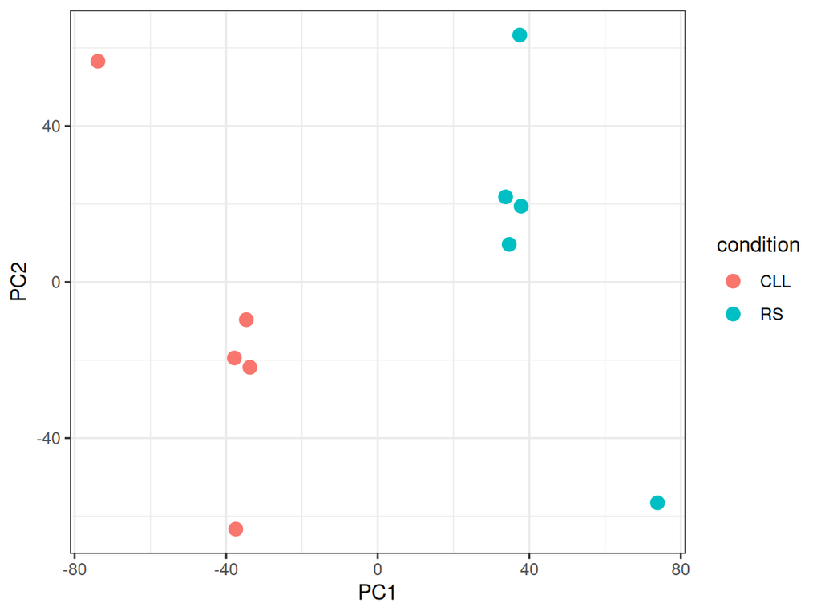

```r
# Variance stabilised transformation
vsdata <- vst(dds, blind = FALSE)

# Extract matrix
vs_mat <- assay(vsdata)

# Adjust for batch (assume batch info is in colData(dds)$batch)
vs_mat_corrected <- removeBatchEffect(vs_mat, batch = colData(dds)$batch)

# PCA on corrected data
pca <- prcomp(t(vs_mat_corrected))

# Make a dataframe for ggplot
pca_df <- data.frame(pca$x,
                     condition = colData(dds)$condition,
                     sample = rownames(colData(dds)))

# Plot
ggplot(pca_df, aes(PC1, PC2, color = condition)) +
  geom_point(size = 3) +
  theme_bw()
```

After batch correction using `limma()`, we can see that the samples were grouped based on the conditions rather than the case origin.

### Differential gene expression analysis

```r
# Generate a table for gene expression
res <- lfcShrink(dds,
                 contrast = c("condition", "RS", "CLL"),
                 type = 'normal')
head(res)
```

```
log2 fold change (MAP): condition RS vs CLL
Wald test p-value: condition RS vs CLL
DataFrame with 6 rows and 6 columns
                  baseMean log2FoldChange     lfcSE      stat     pvalue
                 <numeric>      <numeric> <numeric> <numeric>  <numeric>
ENSG00000000003    9.91641       0.895887  0.833312  0.990459 0.32194991
ENSG00000000419 1891.47077       0.139703  0.396517  0.332506 0.73950700
ENSG00000000457  834.04406      -0.111252  0.453543 -0.241461 0.80919796
ENSG00000000460  745.97776       1.148104  0.494635  2.334663 0.01956106
ENSG00000000938 6416.43017      -0.823010  0.392098 -2.223265 0.02619797
ENSG00000000971  164.63803       1.639649  0.562518  2.887655 0.00388126
                     padj
                <numeric>
ENSG00000000003 0.6484951
ENSG00000000419 0.9110124
ENSG00000000457 0.9378169
ENSG00000000460 0.1389279
ENSG00000000938 0.1660320
ENSG00000000971 0.0473797
```

```r
# Add gene names to a column in expression result
dea.df <- res
gene_map <- unique(tx2gene[, c("gene_id", "gene_name")])
dea.df$gene_id <- rownames(dea.df)
dea.df$gene_name <- gene_map$gene_name[match(rownames(dea.df), gene_map$gene_id)]
head(dea.df)
```

```
log2 fold change (MAP): condition RS vs CLL
Wald test p-value: condition RS vs CLL
DataFrame with 6 rows and 8 columns
                  baseMean log2FoldChange     lfcSE      stat     pvalue
                 <numeric>      <numeric> <numeric> <numeric>  <numeric>
ENSG00000000003    9.91641       0.895887  0.833312  0.990459 0.32194991
ENSG00000000419 1891.47077       0.139703  0.396517  0.332506 0.73950700
ENSG00000000457  834.04406      -0.111252  0.453543 -0.241461 0.80919796
ENSG00000000460  745.97776       1.148104  0.494635  2.334663 0.01956106
ENSG00000000938 6416.43017      -0.823010  0.392098 -2.223265 0.02619797
ENSG00000000971  164.63803       1.639649  0.562518  2.887655 0.00388126
                     padj         gene_id   gene_name
                <numeric>     <character> <character>
ENSG00000000003 0.6484951 ENSG00000000003      TSPAN6
ENSG00000000419 0.9110124 ENSG00000000419        DPM1
ENSG00000000457 0.9378169 ENSG00000000457       SCYL3
ENSG00000000460 0.1389279 ENSG00000000460       FIRRM
ENSG00000000938 0.1660320 ENSG00000000938         FGR
ENSG00000000971 0.0473797 ENSG00000000971         CFH
```

```r
# Save the expression result
saveRDS(dea.df, path_to_save_dea)
```

### Plot heatmap of gene expression

```r
# Import the relevant package
library(pheatmap)
library(RColorBrewer)
```

```r
# Data transformation
vsd <- vst(dds, blind=FALSE)       # Variance-stabilizing transformation
#rld <- rlog(dds_filtered, blind=FALSE)      # Regularized log transformation

# Extract transformed expression matrix
expr_mat <- assay(vsd)

# Calculate z-scores
zscore_mat <- t(scale(t(expr_mat)))
```

```r
# Change column names of the matrix
new_col_names <- str_c(
  colData$case[match(colnames(zscore_mat), colData$samples)],
  "_",
  colData$condition[match(colnames(zscore_mat), colData$samples)]
  )
colnames(zscore_mat) <- new_col_names
```

```r
# Extract main and sub- clusters info from column names
conditions <-  ifelse(grepl("RS", colnames(zscore_mat)), "RT", "CLL")
patient_id <- sub("_.*", "", colnames(zscore_mat))

# Create annotation dataframe
annotation_col <- data.frame(
  Condition = factor(conditions, levels = c("CLL", "RT")),
  Case = factor(patient_id, levels = c("42","27","19","7","24"))
)
annotation_col <- annotation_col[, c("Case", "Condition")]
rownames(annotation_col) <- colnames(zscore_mat)

# Order by Condition and then Case
order_cols <- order(annotation_col$Condition, annotation_col$Case)
zscore_mat_ordered <- zscore_mat[, order_cols]
annotation_col_ordered <- annotation_col[order_cols, , drop = FALSE]
```

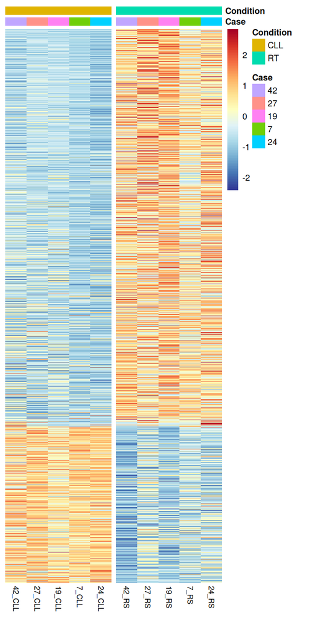

```r
# Filter for significant DE genes
sig_genes <- dea.df[!is.na(dea.df$padj) & dea.df$padj < 0.05, ]

# Order genes by log2FoldChange (descending: up -> down)
gene_order <- sig_genes$gene_id[order(sig_genes$log2FoldChange, decreasing = TRUE)]

# Subset zscore matrix
zscore_mat_sig <- zscore_mat_ordered[gene_order, ]

# Plot heatmap
pheatmap(
  zscore_mat_sig,
  cluster_rows = FALSE,
  cluster_cols = FALSE,
  show_rownames = FALSE,
  color = colorRampPalette(rev(brewer.pal(11, "RdYlBu")))(100),
  annotation_col = annotation_col_ordered,
  fontsize = 8,
  fontsize_row = 7,
  fontsize_col = 7,
  gaps_col = which(diff(as.numeric(factor(annotation_col_ordered$Condition))) != 0)
)
```

### Volcanol plot

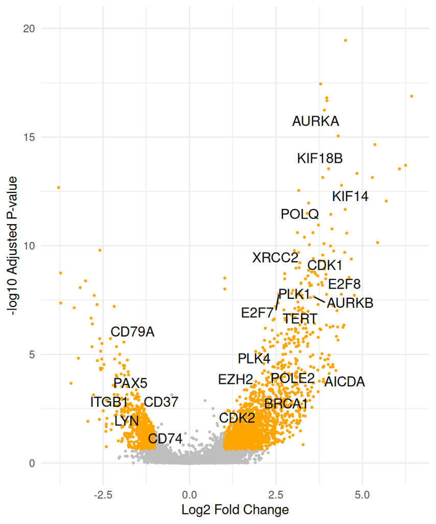

```r
# Make a new column for plotting
dea.df$neglog10padj <- -log10(dea.df$padj)

# Volcano plot
genes_of_interest <- c("PAX5", "CD79A", "CD74", "ITGB1", "CD37", "LYN", "POLQ", "AURKA", "XRCC2", "KIF18B", "PLK1",
                       "E2F7", "KIF14", "AICDA", "PLK4", "CDK1", "EZH2", "AURKB", "E2F8", "BRCA1", "POLE2", "TERT", "CDK2")

ggplot(dea.df, aes(x = log2FoldChange, y = neglog10padj)) +
  geom_point(aes(color = padj < 0.25 & abs(log2FoldChange) > 1), size = 0.5) +
  scale_color_manual(values = c("grey", "orange")) +
  geom_text_repel(
    data = subset(dea.df, gene_name %in% genes_of_interest),
    aes(label = gene_name),
    max.overlaps = Inf,
    size = 4
  ) +
  labs(x = "Log2 Fold Change", y = "-log10 Adjusted P-value") +
  scale_y_continuous(limits = c(0, 20)) +
  theme_minimal() +
  theme(legend.position = "none")
```

Comparison of our volcano plot with the original results (Fig. 5b) shows consistency, supporting the validity of the pipeline used in our study.

## Gene Set Enrichment Analysis (GSEA)

```r
# Import the related libraries in functional enrichment analysis
library(clusterProfiler)
library(enrichplot)
library(msigdbr)
library(org.Hs.eg.db)
```

```r
# Manipulate the expression data
lfc_vector <- dea.df$log2FoldChange # Create a named vector ranked based on the log2 fold change
names(lfc_vector) <- rownames(dea.df)
lfc_vector <- na.omit(lfc_vector) # Omit any NA values
lfc_vector <- sort(lfc_vector, decreasing = TRUE) # Sort the log2 fold change in descending order
```

```r
# Hallmark
HM_gsea <- HM_GSEA(lfc_vector, gene_ident = "ensembl_gene")
```

```r
# Collect the HM GSEA result
HM_GSEA.result <- HM_gsea@result
HM_GSEA_selected.result <- HM_GSEA.result %>%
  as_tibble() %>%
  dplyr::select(c(Description, NES, pvalue, p.adjust))

DT::datatable(HM_GSEA_selected.result, options = list(scrollX = TRUE))
```

|  | Description | NES | pvalue | p.adjust |
| --- | --- | --- | --- | --- |
| 1 | HALLMARK_G2M_CHECKPOINT | 2.360707393179538 | 5.287711283822951e-26 | 2.538101416235017e-24 |
| 2 | HALLMARK_E2F_TARGETS | 2.342006671767761 | 2.136025263509808e-25 | 5.126460632423541e-24 |
| 3 | HALLMARK_EPITHELIAL_MESENCHYMAL_TRANSITION | 2.085783337629176 | 3.327696237099492e-15 | 5.324313979359187e-14 |
| 4 | HALLMARK_MITOTIC_SPINDLE | 1.952275880719286 | 7.814891538877984e-12 | 9.377869846653581e-11 |
| 5 | HALLMARK_COAGULATION | 2.081528263503529 | 1.159066468598626e-10 | 1.112703809854681e-09 |
| 6 | HALLMARK_ESTROGEN_RESPONSE_LATE | 1.884876391047892 | 8.596908221957467e-10 | 6.877526577565973e-09 |
| 7 | HALLMARK_GLYCOLYSIS | 1.814079298824167 | 1.658396127153909e-08 | 1.13718591576268e-07 |
| 8 | HALLMARK_APICAL_JUNCTION | 1.651334483332275 | 1.156650118740316e-05 | 6.939900712441895e-05 |
| 9 | HALLMARK_MTORC1_SIGNALING | 1.612554135394582 | 1.817518286693959e-05 | 9.693430862367782e-05 |
| 10 | HALLMARK_KRAS_SIGNALING_UP | 1.584313653652378 | 6.532087313139843e-05 | 0.0003135401910307125 |

[output cut: 14 more lines]

We will explore the trends of hallmark terms reported from other single-cell pseudobulk studies such as Nadeu et al. (2022) and Hing et al (2023). From those studies, the terms such as E2F targets, Myc targets, and oxidative phosphorylation (OXPHOS) were upregulated.

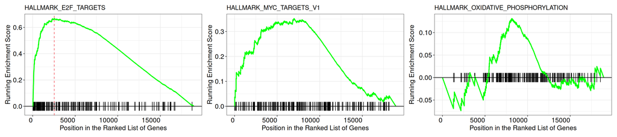

```r
# GSEA plot for HALLMARK_E2F_TARGETS, HALLMARK_MYC_TARGETS_V1, and HALLMARK_OXIDATIVE_PHOSPHORYLATION

E2F_gsea.plt <- gseaplot(HM_gsea,
                          by = "runningScore",
                          title = "HALLMARK_E2F_TARGETS",
                          geneSetID = "HALLMARK_E2F_TARGETS",
                          base_size = 10) +
  theme(axis.text.x = element_text(angle = 0, hjust = 1))

Myc_gsea.plt <- gseaplot(HM_gsea,
                          by = "runningScore",
                          title = "HALLMARK_MYC_TARGETS_V1",
                          geneSetID = "HALLMARK_MYC_TARGETS_V1",
                          base_size = 10) +
  theme(axis.text.x = element_text(angle = 0, hjust = 1))

OXPHOS_gsea.plt <- gseaplot(HM_gsea,
                          by = "runningScore",
                          title = "HALLMARK_OXIDATIVE_PHOSPHORYLATION",
                          geneSetID = "HALLMARK_OXIDATIVE_PHOSPHORYLATION",
                          base_size = 10) +
  theme(axis.text.x = element_text(angle = 0, hjust = 1))

E2F_gsea.plt + Myc_gsea.plt + OXPHOS_gsea.plt
```

From the plots, terms such as E2F and Myc targets were consistent with the two single-cell studies while the OXPHOS trend was not clear.

#### GO:BP

```r
# GO:BP
GOBP_gsea <- GO_GSEA(lfc_vector, gene_ident = "ensembl_gene")
```

```r
# Collect the GSEA result
GOBP_GSEA.result <- GOBP_gsea@result
GOBP_GSEA_selected.result <- GOBP_GSEA.result %>%
  as_tibble() %>%
  dplyr::select(c(Description, NES, pvalue, p.adjust))

DT::datatable(GOBP_GSEA_selected.result, options = list(scrollX = TRUE))
```

|  | Description | NES | pvalue | p.adjust |
| --- | --- | --- | --- | --- |
| 1 | GOBP_MITOTIC_SISTER_CHROMATID_SEGREGATION | 2.305274121160245 | 3.454286528950015e-23 | 2.432681288013048e-20 |
| 2 | GOBP_MITOTIC_NUCLEAR_DIVISION | 2.166930439256345 | 3.314556101640399e-23 | 2.432681288013048e-20 |
| 3 | GOBP_CHROMOSOME_SEGREGATION | 1.988877375428588 | 2.119157679172593e-23 | 2.432681288013048e-20 |
| 4 | GOBP_ORGANELLE_FISSION | 1.94944524131823 | 8.832864403842751e-24 | 2.432681288013048e-20 |
| 5 | GOBP_NUCLEAR_CHROMOSOME_SEGREGATION | 2.086562045589747 | 2.814388451502314e-22 | 1.585626453576403e-19 |
| 6 | GOBP_SISTER_CHROMATID_SEGREGATION | 2.204133357116067 | 1.123871500270815e-21 | 5.276576693771477e-19 |
| 7 | GOBP_POSITIVE_REGULATION_OF_CELL_CYCLE | 2.043105780321524 | 9.857964797024741e-20 | 3.967126690459813e-17 |
| 8 | GOBP_POSITIVE_REGULATION_OF_CELL_CYCLE_PROCESS | 2.080971315011974 | 8.049868193745868e-18 | 2.834559837722764e-15 |
| 9 | GOBP_CYTOPLASMIC_TRANSLATION | -2.672548859413067 | 1.59667490376815e-17 | 4.997592448794309e-15 |
| 10 | GOBP_DNA_REPLICATION | 1.964554807714979 | 2.841748730852392e-16 | 8.005206174811188e-14 |

[output cut: 561 more lines]

We will also explore the trends of GO:BP terms reported from other single-cell studies such as Nadeu et al. (2022) and Hing et al (2023). From those studies, the terms such as OXPHOS and mitochondrial translation were upregulated while BCR signalling was downregulated.

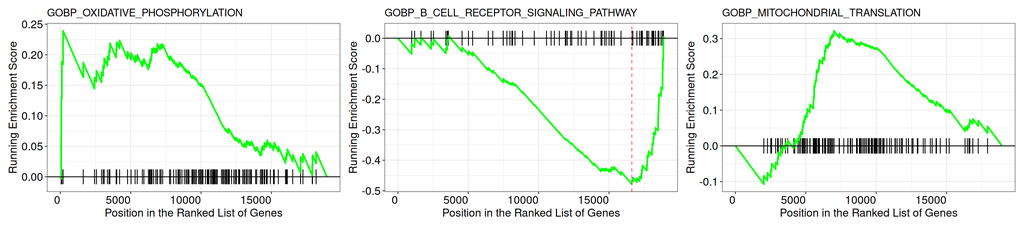

```r
# GSEA plot for GOBP_OXIDATIVE_PHOSPHORYLATION, GOBP_B_CELL_RECEPTOR_SIGNALING_PATHWAY, and GOBP_MITOCHONDRIAL_TRANSLATION

OXPHOS_GO_gsea.plt <- gseaplot(GOBP_gsea,
                          by = "runningScore",
                          title = "GOBP_OXIDATIVE_PHOSPHORYLATION",
                          geneSetID = "GOBP_OXIDATIVE_PHOSPHORYLATION",
                          base_size = 10) +
  theme(axis.text.x = element_text(angle = 0, hjust = 1))

BCR_GO_gsea.plt <- gseaplot(GOBP_gsea,
                          by = "runningScore",
                          title = "GOBP_B_CELL_RECEPTOR_SIGNALING_PATHWAY",
                          geneSetID = "GOBP_B_CELL_RECEPTOR_SIGNALING_PATHWAY",
                          base_size = 10) +
  theme(axis.text.x = element_text(angle = 0, hjust = 1))

mitochondrial_GO_gsea.plt <- gseaplot(GOBP_gsea,
                          by = "runningScore",
                          title = "GOBP_MITOCHONDRIAL_TRANSLATION",
                          geneSetID = "GOBP_MITOCHONDRIAL_TRANSLATION",
                          base_size = 10) +
  theme(axis.text.x = element_text(angle = 0, hjust = 1))

OXPHOS_GO_gsea.plt + BCR_GO_gsea.plt + mitochondrial_GO_gsea.plt
```

Although the terms such as OXPHOS and mitochondrial translation were not siginificantly enriched, the trends were quite upregulated, consistent with the two single-cell studies. Furthermore, BCR signalling was significantly downregulated, similar to that reported in the Nadeu et al. (2022).

```r
# Save gene expression and GSEA data
saveRDS(HM_gsea, path_to_save_hm_gsea)
saveRDS(GOBP_gsea, path_to_save_go_gsea)
```